[figure not shown]

# Customer Support Prediction Project

### by Evangelos Giakoumakis

Icons made by [Freepik](https://www.flaticon.com/authors/freepik) from [www.flaticon.com](https://www.flaticon.com/)

### Project Workflow

1. Data Acquisition
2. Data Exploration
3. Feature Engineering
4. Model Selection
5. Model Development
6. Model Explainability
7. Deployment Plan
8. Success Metrics

library installs

```python
!pip install pandas-profiling
!pip install sweetviz
!pip install pycaret
```

import libraries

```python
import pandas as pd
import numpy as np
import seaborn as sns
import matplotlib.pyplot as plt

from sklearn.model_selection import train_test_split
from catboost import CatBoostClassifier
from sklearn.metrics import classification_report, confusion_matrix
import shap
from sklearn.model_selection import KFold
from sklearn.metrics import accuracy_score

from matplotlib import pyplot as plt
import seaborn as sns

from pandas_profiling import ProfileReport
import sweetviz as sv

from pycaret.classification import *

pd.set_option('display.max_columns', None)
sns.set(color_codes=True)
%matplotlib inline
```

# Data Acquisition

read csv file

```python
df = pd.read_csv('CSP_dataset.csv')
print(df.shape)
df.head()
```

```
(100000, 19)
```

|  | asst_id | product_type | mnfture_wk | contract_st | contract_end | contact_wk | contact_type | issue_type | topic_category | parts_sent | repair_type | repeat_ct | parts_ct | agent_tenure_indays | contact_manager_flg | diagnostics | repeat_parts_sent | region | country |
| --- | --- | --- | --- | --- | --- | --- | --- | --- | --- | --- | --- | --- | --- | --- | --- | --- | --- | --- | --- |
| 0 | 0 | Laptops | 201726 | 201726 | 202125 | 201840 | Voice | NaN | NaN | Hard Drive, Documentation(2) | Hard | 0 | 3 | 1018.0 | 0 | Not_USED | NaN | Hogwarts | NaN |
| 1 | 1 | Laptops | 201650 | 201650 | 201949 | 201840 | Voice | NaN | NaN | Speaker, Chassis | Hard | 0 | 2 | 1018.0 | 0 | Not_USED | NaN | Hogwarts | Zonko's Joke Shop |
| 2 | 2 | Laptops | 201821 | 201821 | 202222 | 201840 | Voice | NaN | NaN | Cables | Hard | 0 | 1 | 1018.0 | 0 | Not_USED | Motherboard, Miscellaneous(2), Hard Drive, Cha... | Hogwarts | Zonko's Joke Shop |
| 3 | 3 | Laptops | 201608 | 201608 | 201908 | 201840 | VOICE | Hard Drive | Booting | Hard Drive | Hard | 0 | 1 | 298.0 | 0 | Effective_Usage | NaN | Hogwarts | Zonko's Joke Shop |
| 4 | 4 | Laptops | 201732 | 201732 | 202032 | 201840 | Voice | NaN | NaN | Battery (Notebook) | Hard | 0 | 1 | 1018.0 | 0 | Not_USED | NaN | Hogwarts | Zonko's Joke Shop |

generate pandas profiling report

```python
profile = ProfileReport(df, title='Customer Support Prediction Report', explorative=True)
profile.to_file("CSP_EDA.html")
```

generate sweetviz report

```python
sv_report = sv.analyze(df)
sv_report.show_html()
```

```
Report SWEETVIZ_REPORT.html was generated! NOTEBOOK/COLAB USERS: the web browser MAY not pop up, regardless, the report IS saved in your notebook/colab files.
```

# Data Exploration

check data types

```python
df.info()
```

```
<class 'pandas.core.frame.DataFrame'>
RangeIndex: 100000 entries, 0 to 99999
Data columns (total 19 columns):
 #   Column               Non-Null Count   Dtype
---  ------               --------------   -----
 0   asst_id              100000 non-null  int64
 1   product_type         99980 non-null   object
 2   mnfture_wk           100000 non-null  int64
 3   contract_st          100000 non-null  int64
 4   contract_end         100000 non-null  int64
 5   contact_wk           100000 non-null  int64
 6   contact_type         99986 non-null   object
 7   issue_type           85958 non-null   object
 8   topic_category       66916 non-null   object
 9   parts_sent           54566 non-null   object
 10  repair_type          100000 non-null  object
 11  repeat_ct            100000 non-null  int64
 12  parts_ct             100000 non-null  int64
 13  agent_tenure_indays  99986 non-null   float64
 14  contact_manager_flg  100000 non-null  int64
 15  diagnostics          100000 non-null  object
 16  repeat_parts_sent    13346 non-null   object
 17  region               99997 non-null   object
 18  country              89998 non-null   object
dtypes: float64(1), int64(8), object(10)
memory usage: 14.5+ MB
```

```python
df.describe()
```

|  | asst_id | mnfture_wk | contract_st | contract_end | contact_wk | repeat_ct | parts_ct | agent_tenure_indays | contact_manager_flg |
| --- | --- | --- | --- | --- | --- | --- | --- | --- | --- |
| count | 100000.000000 | 100000.000000 | 100000.000000 | 100000.000000 | 100000.0 | 100000.000000 | 100000.00000 | 99986.000000 | 100000.000000 |
| mean | 35702.117890 | 201672.108910 | 201671.595910 | 201951.897740 | 201840.0 | 0.074090 | 1.15955 | 985.886844 | 0.012430 |
| std | 25038.092288 | 156.139692 | 158.940598 | 186.777325 | 0.0 | 0.262491 | 1.56942 | 862.044503 | 0.110795 |
| min | 0.000000 | 201001.000000 | 200547.000000 | 201006.000000 | 201840.0 | 0.000000 | 0.00000 | 218.000000 | 0.000000 |
| 25% | 12382.750000 | 201612.000000 | 201612.000000 | 201903.000000 | 201840.0 | 0.000000 | 0.00000 | 536.000000 | 0.000000 |
| 50% | 32898.500000 | 201719.000000 | 201720.000000 | 201938.000000 | 201840.0 | 0.000000 | 1.00000 | 801.000000 | 0.000000 |
| 75% | 57701.250000 | 201808.000000 | 201809.000000 | 202045.000000 | 201840.0 | 0.000000 | 2.00000 | 1018.000000 | 0.000000 |
| max | 82441.000000 | 201927.000000 | 202630.000000 | 202953.000000 | 201840.0 | 3.000000 | 51.00000 | 8922.000000 | 1.000000 |

# asst_id

check for missing values

```python
df.asst_id.isna().sum()
```

```
0
```

check unique values

```python
df.asst_id.nunique()
```

```
82442
```

```python
df.asst_id.unique()
```

```
array([    0,     1,     2, ..., 82439, 82440, 82441], dtype=int64)
```

check for duplicates

```python
df.asst_id.value_counts().head()
```

```
72568    46
5183     18
7715     14
18338     7
11152     6
Name: asst_id, dtype: int64
```

given that asset id seems like it could be the primary key for this table we should eliminate duplicate records

```python
duplicate = df[df.duplicated('asst_id')]
len(duplicate)
```

```
17558
```

i will drop duplicates keeping the first instance of duplicated record

```python
df = df.drop_duplicates(subset='asst_id').reset_index(drop=True)
len(df)
```

```
82442
```

# product_type

```python
df.product_type.isna().sum()
```

```
19
```

Given that we have missing data we can deal with this in the following ways:

- drop the missing records
- impute with placeholder 'No Data' label
- group into 'Other Electronics' category
- try to bring in missing info from another data source

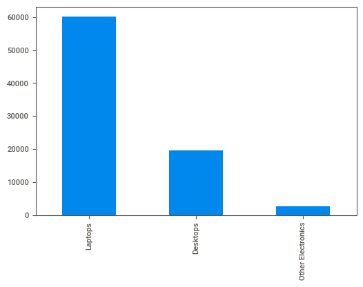

```python
df.product_type.value_counts().plot(kind='bar')
```

# mnfture_wk

```python
df.mnfture_wk.isna().sum()
```

```
0
```

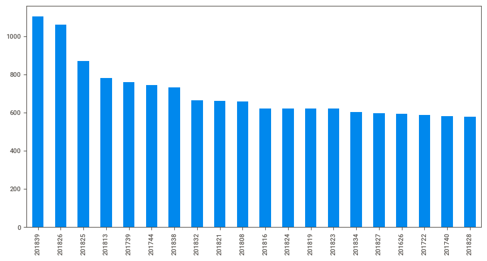

```python
df.mnfture_wk.value_counts().head(20).plot(kind='bar', figsize=(10,5))
```

we could split this into year and week columns for modeling process

# contract_st

```python
df.contract_st.isna().sum()
```

```
0
```

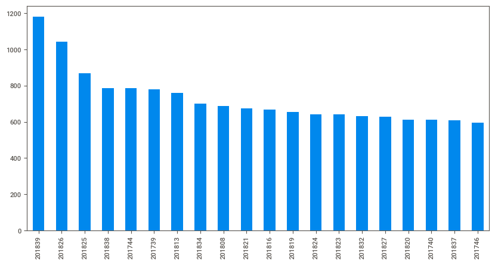

```python
df.contract_st.value_counts().head(20).plot(kind='bar', figsize=(10,5))
```

we could split this into year and week columns for modeling process

# contract_end

```python
df.contract_end.isna().sum()
```

```
0
```

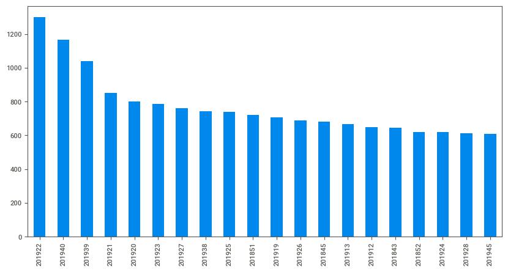

```python
df.contract_end.value_counts().head(20).plot(kind='bar', figsize=(10,5))
```

we could split this into year and week columns for modeling process

# contact_wk

```python
df.contact_wk.isna().sum()
```

```
0
```

```python
df.contact_wk.value_counts()
```

```
201840    82442
Name: contact_wk, dtype: int64
```

this is a constant so we can drop it as it brings no valuable info

# contact_type

```python
df.contact_type.isna().sum()
```

```
9
```

Given that we have missing data we can deal with this in the following ways:

- drop the missing rows
- impute with placeholder 'No Data' label
- group into 'Unknown' category
- try to bring in missing info from another data source

I decided to group with 'Unknown' category since the number or missing records is small and category name makes sense

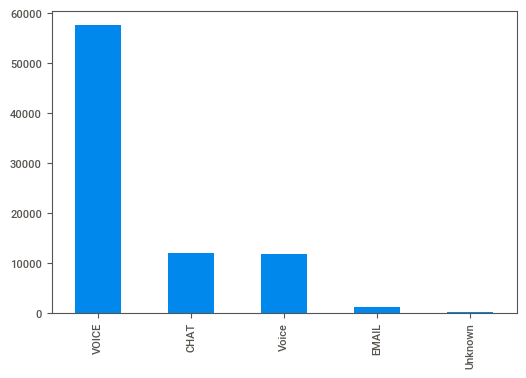

```python
df.contact_type.value_counts().plot(kind='bar')
```

looking at unique values we noticed a 2 categories that differ due to capitalizations so decided to merge into 1 group

# issue_type

```python
df.issue_type.isna().sum()
```

```
11402
```

Given that we have many missing data points we can deal with this in the following ways:

- drop the missing records
- impute with placeholder 'No Data' label
- group into some existing category
- try to bring in missing info from another data source

I decided to impute with 'No Data' label since the is a large number of missing values

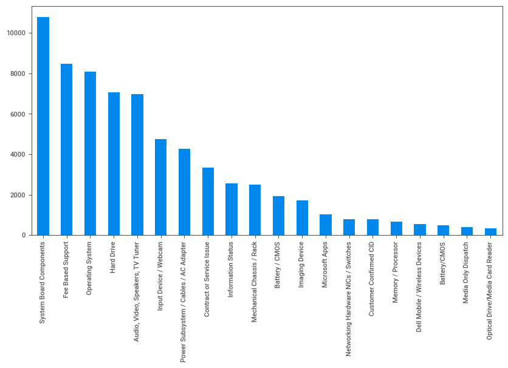

```python
df.issue_type.value_counts().head(20).plot(kind='bar', figsize=(10,5))
```

Given that we have high cardinality it makes sense to group the ones with low counts into a catch all bucket such as 'Others'

# topic_category

```python
df.topic_category.isna().sum()
```

```
27048
```

Given that we have many missing data points we can deal with this in the following ways:

- drop the missing records
- impute with placeholder 'No Data' label
- group into some existing category
- try to bring in missing info from another data source

I decided to impute with 'No Data' label since we are missing a large number of records

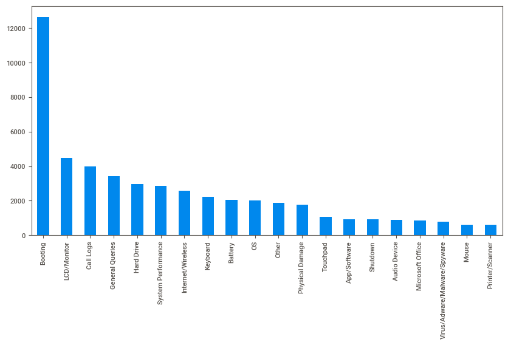

```python
df.topic_category.value_counts().head(20).plot(kind='bar', figsize=(10,5))
```

```python
df.topic_category.unique()
```

```
array([nan, 'Booting', 'General Queries', 'OS', 'Hard Drive', 'Touchpad',
       'Call Logs', 'Internet/Wireless', 'Mouse', 'Motherboard',
       'Keyboard', 'Battery', 'App/Software', 'LCD/Monitor',
       'System Performance', 'Audio Device', 'Initial Setup',
       'Physical Damage', 'Other', 'BIOS', 'Shutdown', 'CD/DVD Drive',
       'System Warning', 'Palmrest', 'Fan', 'Power', 'Antivirus',
       'Bluetooth', 'Graphics Card', 'Printer/Scanner', 'USB', 'Email',
       'Drivers', 'AC Adaptor', 'Controller', 'Microsoft Office',
       'Virus/Adware/Malware/Spyware', 'Media', 'Microsoft Account',
       'Webcam', 'Junk', 'Docking', 'SD Card', 'Touchscreen', 'Memory',
       'DC Port', 'DOA', 'System Configuration', 'Missing Parts',
       'Bit Locker', 'Firmware', 'System update', 'Data', 'Sim Card',
       'Stylus', 'Camera', 'Incorrect Shipment', 'Odor', 'Vmware', 'CPU',
       'Replacement', 'Storage', 'Start-Up', 'Miracast'], dtype=object)
```

Given that we have high cardinality it makes sense to group the ones with low counts into a catch all bucket such as 'Others'

# parts_sent

```python
df.parts_sent.isna().sum()
```

```
37575
```

Given that we have many missing data points we can deal with this in the following ways:

- drop the missing records
- impute with placeholder 'No Data' label
- group into some existing category
- try to bring in missing info from another data source

I decided to impute with 'No Data' label since we are missing a large number of records

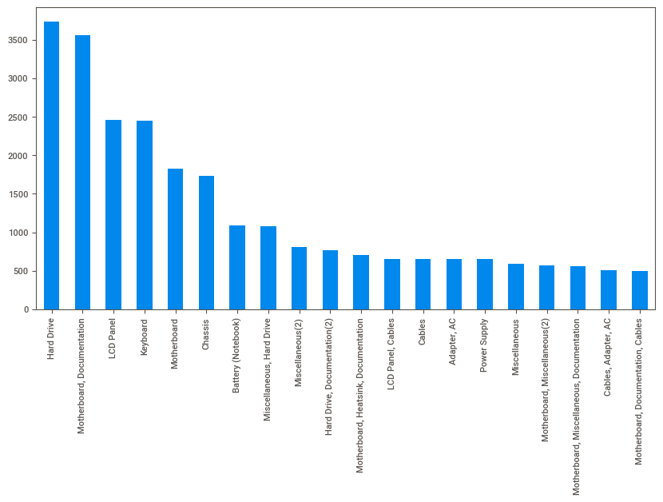

```python
df.parts_sent.value_counts().head(20).plot(kind='bar', figsize=(10,5))
```

```python
df.parts_sent.unique()[:30]
```

```
array(['Hard Drive, Documentation(2)', 'Speaker, Chassis', 'Cables',
       'Hard Drive', 'Battery (Notebook)', nan, 'LCD Panel, Cables',
       'Miscellaneous(2)', 'Motherboard, Documentation',
       'Motherboard, Keyboard, Chassis, Cables', 'LCD Panel',
       'Motherboard', 'Motherboard, Cables',
       'Miscellaneous, Keyboard, Adapter, AC', 'PCBA - Misc.(2)',
       'Fan Assembly', 'Keyboard',
       'Motherboard, Hard Drive, Documentation(2), Cables',
       'Wireless Local Area Network', 'Power Supply', 'Chassis(2)',
       'Graphics Card',
       'Wireless Local Area Network, Motherboard, Miscellaneous(2), Heatsink, Hard Drive',
       'Chassis', 'Heatsink, Chassis',
       'Motherboard, Miscellaneous(2), LCD Panel, Keyboard, Chassis(4), Cables, Battery (Notebook)',
       'Motherboard, Mechanical Hardware, Heatsink, Documentation, Cables',
       'Motherboard, Documentation, Chassis',
       'Keyboard, Battery (Notebook)', 'Miscellaneous(2), Chassis'],
      dtype=object)
```

Given that we have high cardinality it makes sense to group the ones with low counts into a catch all bucket such as 'Others'

Also looking closer we can identify a few groups that could be combined since they look very similar (i.e. Motherboard Documentation, Motherboard Miscelanious, Documenation etc.) Feedback from SME's would be required here but at a first glance seems like an option

# repair_type

```python
df.repair_type.isna().sum()
```

```
0
```

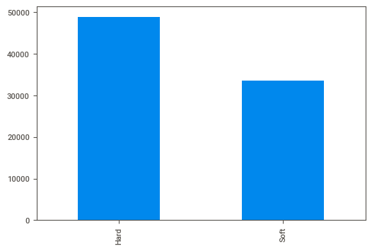

```python
df.repair_type.value_counts().plot(kind='bar')
```

# repeat_ct

```python
df.repeat_ct.isna().sum()
```

```
0
```

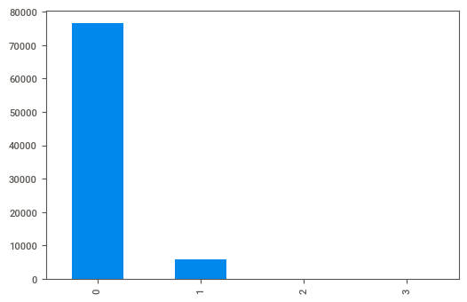

```python
df.repeat_ct.value_counts().plot(kind='bar')
```

# parts_ct

```python
df.parts_ct.isna().sum()
```

```
0
```

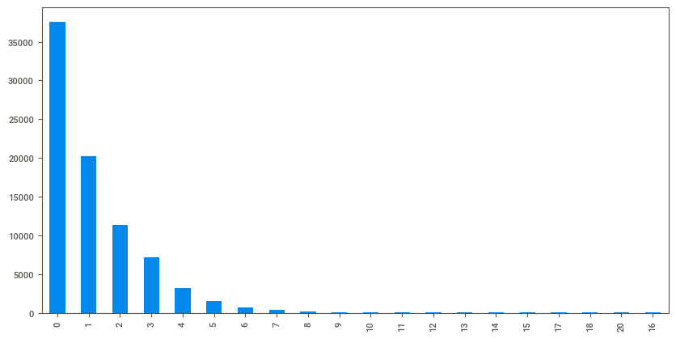

```python
df.parts_ct.value_counts().head(20).plot(kind='bar', figsize=(10,5))
```

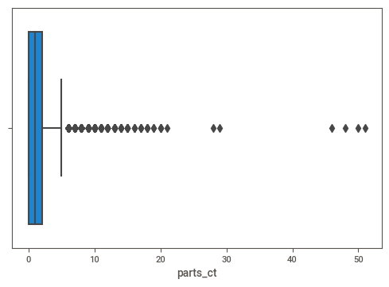

```python
sns.boxplot(x=df.parts_ct)
```

There are many outliers here so we might need to normalize or limit max values

# agent_tenure_indays

```python
df.agent_tenure_indays.isna().sum()
```

```
9
```

Given that we have few missing data points we can deal with this in the following ways:

- drop the missing records
- impute with placeholder 0 or -1 value
- group into some existing category
- try to bring in missing info from another data source

I decided to impute with 0 label since it makes sense as a missing value

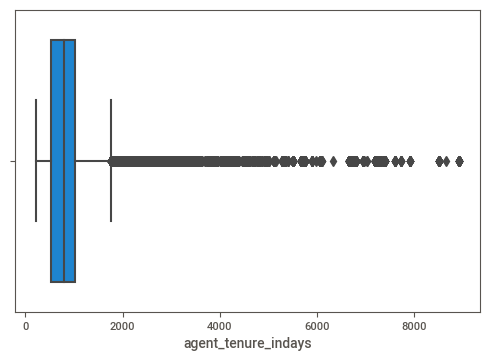

```python
sns.boxplot(x=df.agent_tenure_indays)
```

There are many outliers here so we might need to normalize or limit max values

# contact_manager_flg

```python
df.contact_manager_flg.isna().sum()
```

```
0
```

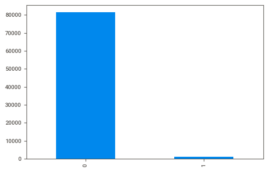

```python
df.contact_manager_flg.value_counts().plot(kind='bar')
```

# diagnostics

```python
df.diagnostics.isna().sum()
```

```
0
```

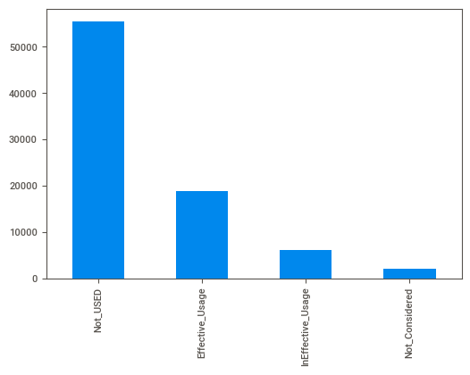

```python
df.diagnostics.value_counts().plot(kind='bar')
```

# repeat_parts_sent

```python
df.repeat_parts_sent.isna().sum()
```

```
71603
```

Given that we have many missing data points we can deal with this in the following ways:

- drop the missing records
- impute with placeholder 'No Parts Sent' value
- group into some existing category
- try to bring in missing info from another data source

I decided to impute with 'No Parts Sent' label since it makes sense in this scenario

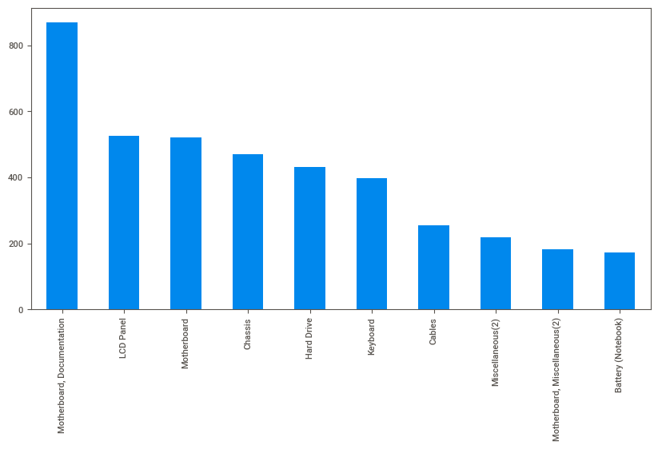

```python
df.repeat_parts_sent.value_counts().head(10).plot(kind='bar', figsize=(10,5))
```

Given that we have high cardinality it makes sense to group the ones with low counts into a catch all bucket such as 'Others'

# region

```python
df.region.isna().sum()
```

```
3
```

Given that we have few missing data points we can deal with this in the following ways:

- drop the missing records
- impute with placeholder 'Unknown' value
- group into some existing category
- try to bring in missing info from another data source

I decided to group to majority category since there were only 3 missing values and that didnt warrant creation of new category

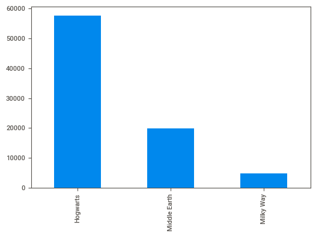

```python
df.region.value_counts().plot(kind='bar')
```

# country

```python
df.country.isna().sum()
```

```
8253
```

Given that we have many missing data points we can deal with this in the following ways:

- drop the missing records
- impute with placeholder 'Unknown' value
- group into some existing category
- try to bring in missing info from another data source

I decided to impute with 'Unknown' value since there is a large amount of missing data

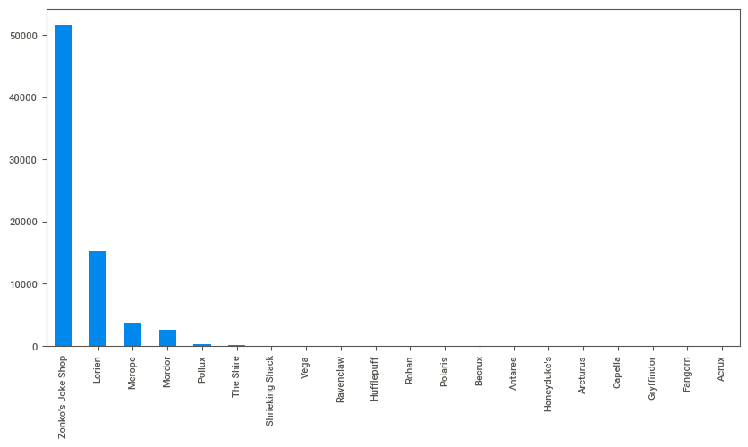

```python
df.country.value_counts().head(20).plot(kind='bar', figsize=(10,5))
```

```python
df.country.unique()
```

```
array([nan, "Zonko's Joke Shop", 'Lorien', 'The Shire', 'Mordor',
       'Merope', 'Pollux', 'Three Broomsticks', 'Shrieking Shack',
       'Ravenclaw', 'Hufflepuff', 'Capella', "Honeyduke's", 'Polaris',
       'Fomalhaut', 'Hobbiton', 'Sabik', 'Spica', 'Becrux', 'Vega',
       'Rohan', 'Gondor', 'Aldebaran', 'Mintaka', 'Rukbat', 'Acrux',
       'Canopus', 'Rigel', 'Antares', 'Diagon Alley', 'Gryffindor',
       'Isengard', 'Procyon', 'Bree', 'Pleione', 'Regulus', 'Erebor',
       'Fangorn', 'Castor', 'Alcor', 'Minas Tirith', 'Arcturus',
       'Rivendell', 'Mirkwood', 'Sirius', 'Altair', 'Betelgeuse',
       "Helm's Deep", 'Muscida', "Hog's Head Inn", 'Bellatrix', 'Mizar',
       'Slytherin', 'Moria'], dtype=object)
```

Given that we have high cardinality it makes sense to group the ones with low counts into a catch all bucket such as 'Others'

# Heatmap - relationships

|  | asst_id | mnfture_wk | contract_st | contract_end | contact_wk | repeat_ct | parts_ct | agent_tenure_indays | contact_manager_flg |
| --- | --- | --- | --- | --- | --- | --- | --- | --- | --- |
| asst_id | 1.000000 | -0.002306 | -0.002195 | -0.002081 | NaN | -0.005503 | -0.001814 | -0.004224 | -0.003640 |
| mnfture_wk | -0.002306 | 1.000000 | 0.980835 | 0.633925 | NaN | 0.033504 | 0.107435 | -0.037940 | 0.047249 |
| contract_st | -0.002195 | 0.980835 | 1.000000 | 0.626839 | NaN | 0.031618 | 0.102163 | -0.037162 | 0.047032 |
| contract_end | -0.002081 | 0.633925 | 0.626839 | 1.000000 | NaN | 0.086066 | 0.227554 | 0.005141 | 0.013969 |
| contact_wk | NaN | NaN | NaN | NaN | NaN | NaN | NaN | NaN | NaN |
| repeat_ct | -0.005503 | 0.033504 | 0.031618 | 0.086066 | NaN | 1.000000 | 0.155937 | 0.008195 | 0.027535 |
| parts_ct | -0.001814 | 0.107435 | 0.102163 | 0.227554 | NaN | 0.155937 | 1.000000 | 0.014787 | 0.035495 |
| agent_tenure_indays | -0.004224 | -0.037940 | -0.037162 | 0.005141 | NaN | 0.008195 | 0.014787 | 1.000000 | -0.018451 |
| contact_manager_flg | -0.003640 | 0.047249 | 0.047032 | 0.013969 | NaN | 0.027535 | 0.035495 | -0.018451 | 1.000000 |

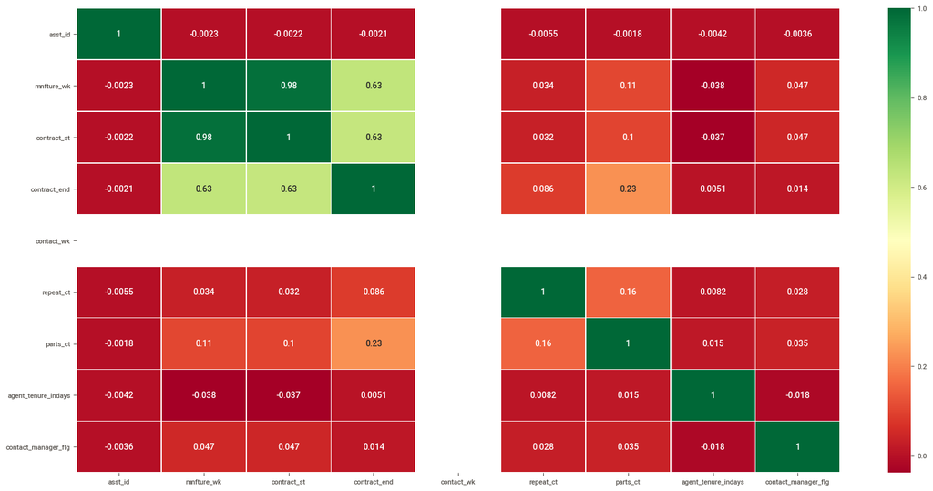

```python
plt.figure(figsize=(20,10))
c = df.corr()
sns.heatmap(c, cmap="RdYlGn", annot=True, linewidths=.5)
c
```

A decision will have to be made as to which of those we would like to keep.

# Feature Engineering

### product_type

```python
df.product_type.fillna('No Data', inplace=True)
print(df.product_type.value_counts())
```

```
Laptops              60123
Desktops             19574
Other Electronics     2726
No Data                 19
Name: product_type, dtype: int64
```

### contact_type

```python
df.contact_type.fillna('Unknown', inplace=True)
df.contact_type.replace("Voice", "VOICE", inplace=True)
print(df.contact_type.value_counts())
```

```
VOICE      69304
CHAT       11968
EMAIL       1072
Unknown       98
Name: contact_type, dtype: int64
```

### issue_type

```python
df.issue_type.fillna('No Data', inplace=True)
print(df.issue_type.value_counts().head(15))
```

```
No Data                                  11402
System Board Components                  10789
Fee Based Support                         8458
Operating System                          8076
Hard Drive                                7047
Audio, Video, Speakers, TV Tuner          6961
Input Device / Webcam                     4763
Power Subsystem / Cables / AC Adapter     4270
Contract or Service Issue                 3329
Information Status                        2545
Mechanical Chassis / Rack                 2496
Battery / CMOS                            1919
Imaging Device                            1714
Microsoft Apps                            1026
Networking Hardware NICs / Switches        778
Name: issue_type, dtype: int64
```

### topic_category

```python
df.topic_category.fillna('No Data', inplace=True)
print(df.topic_category.value_counts().head(15))
```

```
No Data               27048
Booting               12669
LCD/Monitor            4473
Call Logs              3971
General Queries        3435
Hard Drive             2964
System Performance     2866
Internet/Wireless      2579
Keyboard               2222
Battery                2035
OS                     2012
Other                  1858
Physical Damage        1757
Touchpad               1072
App/Software            924
Name: topic_category, dtype: int64
```

### parts_sent

```python
df.parts_sent.fillna('No Data', inplace=True)
print(df.parts_sent.value_counts().head(15))
```

```
No Data                                 37575
Hard Drive                               3730
Motherboard, Documentation               3554
LCD Panel                                2457
Keyboard                                 2444
Motherboard                              1827
Chassis                                  1729
Battery (Notebook)                       1088
Miscellaneous, Hard Drive                1082
Miscellaneous(2)                          806
Hard Drive, Documentation(2)              767
Motherboard, Heatsink, Documentation      700
LCD Panel, Cables                         656
Cables                                    653
Power Supply                              649
Name: parts_sent, dtype: int64
```

### agent_tenure_indays

```python
df.agent_tenure_indays.fillna(0, inplace=True)
print(df.agent_tenure_indays.value_counts().head(15))
```

```
1018.0    11687
686.0      1770
305.0      1544
840.0      1296
676.0      1160
720.0      1053
695.0      1018
463.0       937
781.0       891
298.0       790
266.0       766
329.0       759
768.0       757
758.0       752
592.0       661
Name: agent_tenure_indays, dtype: int64
```

### repeat_parts_sent

```python
df.repeat_parts_sent.fillna('No Parts Sent', inplace=True)
print(df.repeat_parts_sent.value_counts().head(15))
```

```
No Parts Sent                           71603
Motherboard, Documentation                871
LCD Panel                                 525
Motherboard                               521
Chassis                                   470
Hard Drive                                432
Keyboard                                  398
Cables                                    254
Miscellaneous(2)                          218
Motherboard, Miscellaneous(2)             183
Battery (Notebook)                        173
Motherboard, Heatsink, Documentation      162
Motherboard, Documentation, Cables        156
Miscellaneous, Hard Drive                 151
PCBA - Misc.                              149
Name: repeat_parts_sent, dtype: int64
```

### region

```python
df.region.fillna('Hogwarts', inplace=True)
print(df.region.value_counts())
```

```
Hogwarts        57678
Middle Earth    19903
Milky Way        4861
Name: region, dtype: int64
```

### country

```python
df.country.fillna('Unknown', inplace=True)
print(df.country.value_counts().head(15))
```

```
Zonko's Joke Shop    51683
Lorien               15180
Unknown               8253
Merope                3727
Mordor                2536
Pollux                 340
The Shire              165
Shrieking Shack         71
Vega                    58
Ravenclaw               50
Hufflepuff              44
Rohan                   30
Polaris                 30
Becrux                  24
Antares                 19
Name: country, dtype: int64
```

### Treat high Cardinality

Function to help us bucket all features with count less that given number into a single group

```python
def grouper(df, col, cutoff, replace_txt):
    count = df[col].value_counts()
    tmp_list = list(count[count > cutoff].keys())
    df[col] = df[col].map(lambda x: not_replace_value(x, replace_txt, tmp_list))

    return df

def not_replace_value(x, replace_val, lst):
    if x in lst:
        return x
    else:
        return replace_val
```

Plan is to go through all features with high cardinality and decrease number of distinct values. General rule I followed was to group into 'Other' all values with low number of counts based on data distribution

### issue_type

```python
df.issue_type.value_counts().head(20)
```

```
No Data                                  11402
System Board Components                  10789
Fee Based Support                         8458
Operating System                          8076
Hard Drive                                7047
Audio, Video, Speakers, TV Tuner          6961
Input Device / Webcam                     4763
Power Subsystem / Cables / AC Adapter     4270
Contract or Service Issue                 3329
Information Status                        2545
Mechanical Chassis / Rack                 2496
Battery / CMOS                            1919
Imaging Device                            1714
Microsoft Apps                            1026
Networking Hardware NICs / Switches        778
Customer Confirmed CID                     777
Memory / Processor                         671
Dell Mobile / Wireless Devices             534
Battery/CMOS                               499
Media Only Dispatch                        401
Name: issue_type, dtype: int64
```

```python
df = grouper(df, 'issue_type', 1000, "Other Issue")
```

```python
df.issue_type.value_counts()
```

```
No Data                                  11402
System Board Components                  10789
Fee Based Support                         8458
Operating System                          8076
Other Issue                               7647
Hard Drive                                7047
Audio, Video, Speakers, TV Tuner          6961
Input Device / Webcam                     4763
Power Subsystem / Cables / AC Adapter     4270
Contract or Service Issue                 3329
Information Status                        2545
Mechanical Chassis / Rack                 2496
Battery / CMOS                            1919
Imaging Device                            1714
Microsoft Apps                            1026
Name: issue_type, dtype: int64
```

### topic_category

```python
df.topic_category.value_counts().head(25)
```

```
No Data                         27048
Booting                         12669
LCD/Monitor                      4473
Call Logs                        3971
General Queries                  3435
Hard Drive                       2964
System Performance               2866
Internet/Wireless                2579
Keyboard                         2222
Battery                          2035
OS                               2012
Other                            1858
Physical Damage                  1757
Touchpad                         1072
App/Software                      924
Shutdown                          912
Audio Device                      885
Microsoft Office                  862
Virus/Adware/Malware/Spyware      774
Mouse                             615
Printer/Scanner                   611
Fan                               571
Drivers                           477
Motherboard                       473
Docking                           391
Name: topic_category, dtype: int64
```

```python
df = grouper(df, 'topic_category', 900, "Other")
```

```python
df.topic_category.value_counts()
```

```
No Data               27048
Booting               12669
Other                 11503
LCD/Monitor            4473
Call Logs              3971
General Queries        3435
Hard Drive             2964
System Performance     2866
Internet/Wireless      2579
Keyboard               2222
Battery                2035
OS                     2012
Physical Damage        1757
Touchpad               1072
App/Software            924
Shutdown                912
Name: topic_category, dtype: int64
```

### parts_sent

```python
df.parts_sent.value_counts().head(25)
```

```
No Data                                      37575
Hard Drive                                    3730
Motherboard, Documentation                    3554
LCD Panel                                     2457
Keyboard                                      2444
Motherboard                                   1827
Chassis                                       1729
Battery (Notebook)                            1088
Miscellaneous, Hard Drive                     1082
Miscellaneous(2)                               806
Hard Drive, Documentation(2)                   767
Motherboard, Heatsink, Documentation           700
LCD Panel, Cables                              656
Cables                                         653
Power Supply                                   649
Adapter, AC                                    649
Miscellaneous                                  589
Motherboard, Miscellaneous(2)                  569
Motherboard, Miscellaneous, Documentation      560
Cables, Adapter, AC                            503
Motherboard, Documentation, Cables             495
Mouse                                          465
PCBA - Misc.                                   384
Chassis(2)                                     321
Miscellaneous(2), LCD Panel                    318
Name: parts_sent, dtype: int64
```

```python
df = grouper(df, 'parts_sent', 1000, "Other Part")
```

```python
df.parts_sent.value_counts()
```

```
No Data                       37575
Other Part                    26956
Hard Drive                     3730
Motherboard, Documentation     3554
LCD Panel                      2457
Keyboard                       2444
Motherboard                    1827
Chassis                        1729
Battery (Notebook)             1088
Miscellaneous, Hard Drive      1082
Name: parts_sent, dtype: int64
```

### repeat_parts_sent

```python
df.repeat_parts_sent.value_counts().head(25)
```

```
No Parts Sent                                71603
Motherboard, Documentation                     871
LCD Panel                                      525
Motherboard                                    521
Chassis                                        470
Hard Drive                                     432
Keyboard                                       398
Cables                                         254
Miscellaneous(2)                               218
Motherboard, Miscellaneous(2)                  183
Battery (Notebook)                             173
Motherboard, Heatsink, Documentation           162
Motherboard, Documentation, Cables             156
Miscellaneous, Hard Drive                      151
PCBA - Misc.                                   149
LCD Panel, Cables                              136
Miscellaneous                                  127
Motherboard, Miscellaneous, Documentation      107
Chassis(2)                                     107
Adapter, AC                                    106
Cables, Adapter, AC                            103
Memory                                          98
Hard Drive, Documentation(2)                    97
Motherboard, Cables                             97
Power Supply                                    77
Name: repeat_parts_sent, dtype: int64
```

```python
df = grouper(df, 'repeat_parts_sent', 200, "Other Part Sent")
```

```python
df.repeat_parts_sent.value_counts()
```

```
No Parts Sent                 71603
Other Part Sent                7150
Motherboard, Documentation      871
LCD Panel                       525
Motherboard                     521
Chassis                         470
Hard Drive                      432
Keyboard                        398
Cables                          254
Miscellaneous(2)                218
Name: repeat_parts_sent, dtype: int64
```

### country

```python
df.country.value_counts().head(25)
```

```
Zonko's Joke Shop    51683
Lorien               15180
Unknown               8253
Merope                3727
Mordor                2536
Pollux                 340
The Shire              165
Shrieking Shack         71
Vega                    58
Ravenclaw               50
Hufflepuff              44
Rohan                   30
Polaris                 30
Becrux                  24
Antares                 19
Arcturus                18
Honeyduke's             18
Capella                 15
Gryffindor              13
Fangorn                 13
Acrux                   12
Sirius                  11
Spica                   11
Canopus                 10
Three Broomsticks        9
Name: country, dtype: int64
```

```python
df = grouper(df, 'country', 50, "Other Country")
```

```python
df.country.value_counts()
```

```
Zonko's Joke Shop    51683
Lorien               15180
Unknown               8253
Merope                3727
Mordor                2536
Other Country          429
Pollux                 340
The Shire              165
Shrieking Shack         71
Vega                    58
Name: country, dtype: int64
```

### Treat High Feature Correlation

This can be tested during modeling phase to ensure it is the best approach

### contract_st and mnfture_wk

I decided to drop mnfture_wk and use contract_st. They both provide similar information and the main reason was due to better distribution.

This can be tested during modeling phase to ensure it is the best approach

```python
df.drop(['contact_wk', 'country', 'mnfture_wk'], axis=1, inplace=True)
df.shape
```

```
(82442, 16)
```

Re-check dataframe to ensure there are no more issues

```python
profile = ProfileReport(df, title='Customer Support Prediction Report', explorative=True)
profile.to_file("CSP_EDA2.html")
```

# Model Selection

Due to time limitation I will only create one of these of models, however any of these could be easily developed folowing same methodology.

### Binary Classification with repair_type label

fix prediction label (turn text into int)

```python
def label_fix(x):
    if x == 'Hard':
        return 1
    else:
        return 0

df['repair_type_label'] = df.repair_type.map(lambda x: label_fix(x))
```

```python
df.head()
```

|  | asst_id | product_type | contract_st | contract_end | contact_type | issue_type | topic_category | parts_sent | repair_type | repeat_ct | parts_ct | agent_tenure_indays | contact_manager_flg | diagnostics | repeat_parts_sent | region | repair_type_label |
| --- | --- | --- | --- | --- | --- | --- | --- | --- | --- | --- | --- | --- | --- | --- | --- | --- | --- |
| 0 | 0 | Laptops | 201726 | 202125 | VOICE | No Data | No Data | Other Part | Hard | 0 | 3 | 1018.0 | 0 | Not_USED | No Parts Sent | Hogwarts | 1 |
| 1 | 1 | Laptops | 201650 | 201949 | VOICE | No Data | No Data | Other Part | Hard | 0 | 2 | 1018.0 | 0 | Not_USED | No Parts Sent | Hogwarts | 1 |
| 2 | 2 | Laptops | 201821 | 202222 | VOICE | No Data | No Data | Other Part | Hard | 0 | 1 | 1018.0 | 0 | Not_USED | Other Part Sent | Hogwarts | 1 |
| 3 | 3 | Laptops | 201608 | 201908 | VOICE | Hard Drive | Booting | Hard Drive | Hard | 0 | 1 | 298.0 | 0 | Effective_Usage | No Parts Sent | Hogwarts | 1 |
| 4 | 4 | Laptops | 201732 | 202032 | VOICE | No Data | No Data | Battery (Notebook) | Hard | 0 | 1 | 1018.0 | 0 | Not_USED | No Parts Sent | Hogwarts | 1 |

### Treat Data Imbalance

```python
df.repair_type_label.value_counts()
```

```
1    48939
0    33503
Name: repair_type_label, dtype: int64
```

undersample majority class

```python
class0_undersampling = df[df.repair_type_label == 0].sample(n = 33503, random_state=12)
print("Class 0 Shape:", class0_undersampling.shape)
class1_undersampling = df[df.repair_type_label == 1].sample(n = 33503, random_state=12)
print("Class 1 Shape:", class1_undersampling.shape)
```

```
Class 0 Shape: (33503, 17)
Class 1 Shape: (33503, 17)
```

```python
frames = [class0_undersampling, class1_undersampling]
train_data = pd.concat(frames)
print("Train Dataset Shape:", train_data.shape)
```

```
Train Dataset Shape: (67006, 17)
```

remove problematic correlated features

```python
train_data.drop(['repair_type', 'parts_ct', 'parts_sent', 'issue_type'], axis=1, inplace=True)
```

### Train - Test split

```python
y = train_data['repair_type_label']
X = train_data.drop(columns=['repair_type_label', 'asst_id'])

X_train, X_test, y_train, y_test = train_test_split(X, y, test_size=0.25, random_state=41)
```

```python
X_train.shape
```

```
(50254, 11)
```

```python
X_test.shape
```

```
(16752, 11)
```

## Model Comparison

I will use PyCaret library to easily compare various machine learning models and select the best one for this scenario

```python
df.drop(['repair_type', 'parts_ct', 'parts_sent', 'issue_type'], axis=1, inplace=True)
```

```python
clf1 = setup(df, target = 'repair_type_label', session_id=123, log_experiment=True, experiment_name='Repair Type Classification')
```

|  | Description | Value |
| --- | --- | --- |
| 0 | session_id | 123 |
| 1 | Target | repair_type_label |
| 2 | Target Type | Binary |
| 3 | Label Encoded | 0: 0, 1: 1 |
| 4 | Original Data | (82442, 13) |
| 5 | Missing Values | False |
| 6 | Numeric Features | 4 |
| 7 | Categorical Features | 8 |
| 8 | Ordinal Features | False |
| 9 | High Cardinality Features | False |
| 10 | High Cardinality Method | None |
| 11 | Transformed Train Set | (57709, 48) |
| 12 | Transformed Test Set | (24733, 48) |
| 13 | Shuffle Train-Test | True |
| 14 | Stratify Train-Test | False |
| 15 | Fold Generator | StratifiedKFold |
| 16 | Fold Number | 10 |
| 17 | CPU Jobs | -1 |
| 18 | Use GPU | False |
| 19 | Log Experiment | True |
| 20 | Experiment Name | Repair Type Classification |
| 21 | USI | 8e88 |
| 22 | Imputation Type | simple |
| 23 | Iterative Imputation Iteration | None |
| 24 | Numeric Imputer | mean |
| 25 | Iterative Imputation Numeric Model | None |
| 26 | Categorical Imputer | constant |
| 27 | Iterative Imputation Categorical Model | None |
| 28 | Unknown Categoricals Handling | least_frequent |
| 29 | Normalize | False |
| 30 | Normalize Method | None |
| 31 | Transformation | False |
| 32 | Transformation Method | None |
| 33 | PCA | False |
| 34 | PCA Method | None |
| 35 | PCA Components | None |
| 36 | Ignore Low Variance | False |
| 37 | Combine Rare Levels | False |
| 38 | Rare Level Threshold | None |
| 39 | Numeric Binning | False |
| 40 | Remove Outliers | False |
| 41 | Outliers Threshold | None |
| 42 | Remove Multicollinearity | False |
| 43 | Multicollinearity Threshold | None |
| 44 | Clustering | False |
| 45 | Clustering Iteration | None |
| 46 | Polynomial Features | False |
| 47 | Polynomial Degree | None |
| 48 | Trignometry Features | False |
| 49 | Polynomial Threshold | None |
| 50 | Group Features | False |
| 51 | Feature Selection | False |
| 52 | Features Selection Threshold | None |
| 53 | Feature Interaction | False |
| 54 | Feature Ratio | False |
| 55 | Interaction Threshold | None |
| 56 | Fix Imbalance | False |
| 57 | Fix Imbalance Method | SMOTE |

[output not shown]

```python
best_model = compare_models()
```

|  | Model | Accuracy | AUC | Recall | Prec. | F1 | Kappa | MCC | TT (Sec) |
| --- | --- | --- | --- | --- | --- | --- | --- | --- | --- |
| catboost | CatBoost Classifier | 0.8587 | 0.9366 | 0.8775 | 0.8841 | 0.8808 | 0.7074 | 0.7075 | 16.3810 |
| xgboost | Extreme Gradient Boosting | 0.8579 | 0.9356 | 0.8764 | 0.8837 | 0.8800 | 0.7057 | 0.7058 | 1.9720 |
| lightgbm | Light Gradient Boosting Machine | 0.8539 | 0.9325 | 0.8726 | 0.8807 | 0.8766 | 0.6975 | 0.6975 | 0.1580 |
| rf | Random Forest Classifier | 0.8427 | 0.9226 | 0.8630 | 0.8713 | 0.8671 | 0.6743 | 0.6745 | 1.2200 |
| gbc | Gradient Boosting Classifier | 0.8319 | 0.9164 | 0.8785 | 0.8450 | 0.8614 | 0.6479 | 0.6488 | 1.7020 |
| et | Extra Trees Classifier | 0.8260 | 0.9073 | 0.8516 | 0.8553 | 0.8534 | 0.6394 | 0.6395 | 1.5590 |
| ada | Ada Boost Classifier | 0.8182 | 0.9053 | 0.8606 | 0.8382 | 0.8492 | 0.6205 | 0.6209 | 0.4850 |
| dt | Decision Tree Classifier | 0.7951 | 0.7876 | 0.8280 | 0.8276 | 0.8278 | 0.5748 | 0.5748 | 0.1030 |
| lda | Linear Discriminant Analysis | 0.7847 | 0.8522 | 0.8721 | 0.7885 | 0.8282 | 0.5420 | 0.5470 | 0.1790 |
| ridge | Ridge Classifier | 0.7845 | 0.0000 | 0.8733 | 0.7876 | 0.8282 | 0.5412 | 0.5464 | 0.0440 |
| knn | K Neighbors Classifier | 0.7482 | 0.8118 | 0.8000 | 0.7818 | 0.7908 | 0.4747 | 0.4749 | 0.3430 |
| lr | Logistic Regression | 0.6899 | 0.6762 | 0.8099 | 0.7098 | 0.7565 | 0.3347 | 0.3403 | 0.2810 |
| nb | Naive Bayes | 0.6204 | 0.8166 | 0.3934 | 0.9257 | 0.5521 | 0.3059 | 0.3920 | 0.0560 |
| qda | Quadratic Discriminant Analysis | 0.5903 | 0.5633 | 0.7053 | 0.6493 | 0.6661 | 0.1269 | 0.1339 | 0.1440 |
| svm | SVM - Linear Kernel | 0.5604 | 0.0000 | 0.6698 | 0.6436 | 0.5508 | 0.0689 | 0.0795 | 0.9190 |

As we can see from above table catboost performed the best out of all models tested and thus I will be using it to create my final model as I valued performance above else in this situation.

In Addition to that, given that our dataset contains many categorical text features which Catboost can process will simplify data preparation.

However in a real world situation where speed of execution or limited resource consumption might be of the outmost importance someoene could choose either xgboost or lightgbm as they provide similar results in less time.

# Model Development

Specify categorical features

```python
cat_feat_list = ['product_type', 'contact_type', 'topic_category', 'diagnostics', 'repeat_parts_sent', 'region']
```

Create and configure model parameters

Treating overfitting by regularizing and using overfitting detector in conjuction with simple model

```python
params = {'loss_function':'Logloss',
          'eval_metric':'AUC',
          'cat_features': cat_feat_list,
          'verbose': 200,
          'random_seed': 23,
          'od_type': 'Iter',
          'od_wait': 5,
          'l2_leaf_reg': 5,
          'learning_rate': 0.1,
          'max_depth': 4
         }

cbc = CatBoostClassifier(**params)
cbc.fit(X_train, y_train,
        eval_set=(X_test, y_test),
        use_best_model=True,
        plot=True
       );
```

```
0:	test: 0.8403928	best: 0.8403928 (0)	total: 47.4ms	remaining: 47.4s
200:	test: 0.9239670	best: 0.9239718 (199)	total: 6.71s	remaining: 26.7s
Stopped by overfitting detector  (5 iterations wait)

bestTest = 0.9265443613
bestIteration = 317

Shrink model to first 318 iterations.
```

```python
# ToDo: exhaustive hyperparameter tuning of model
```

### Model Performance

```python
y_pred = cbc.predict(X_test)

print("Confusion Matrix")
print(confusion_matrix(y_test, y_pred))

print('\nClassification Report ')
print(classification_report(y_test, y_pred))
```

```
Confusion Matrix
[[7300 1014]
 [1597 6841]]

Classification Report
              precision    recall  f1-score   support

           0       0.82      0.88      0.85      8314
           1       0.87      0.81      0.84      8438

    accuracy                           0.84     16752
   macro avg       0.85      0.84      0.84     16752
weighted avg       0.85      0.84      0.84     16752
```

### Feature Importance

```python
feature_importance_df = cbc.get_feature_importance(prettified=True)
feature_importance_df
```

|  | Feature Id | Importances |
| --- | --- | --- |
| 0 | agent_tenure_indays | 38.406041 |
| 1 | repeat_parts_sent | 33.051742 |
| 2 | contract_end | 7.698692 |
| 3 | topic_category | 7.212592 |
| 4 | contract_st | 3.920142 |
| 5 | diagnostics | 2.986829 |
| 6 | region | 2.342876 |
| 7 | contact_type | 1.787038 |
| 8 | repeat_ct | 1.649875 |
| 9 | product_type | 0.799865 |
| 10 | contact_manager_flg | 0.144309 |

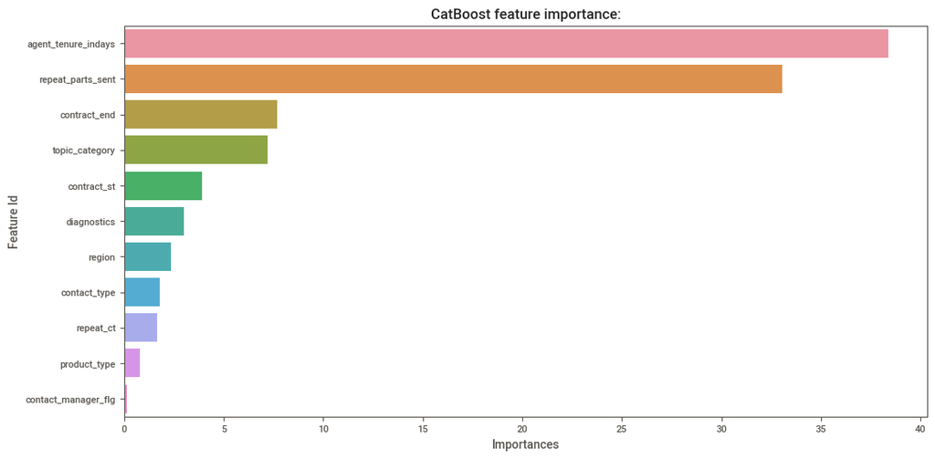

```python
plt.figure(figsize=(12, 6));
sns.barplot(x="Importances", y="Feature Id", data=feature_importance_df);
plt.title('CatBoost feature importance:');
```

# Model Explainability - SHAP

Create Tree Explainer in order to help interpret model desicions

```python
explainer = shap.TreeExplainer(cbc) # insert your model
shap_values = explainer.shap_values(X) # insert your train object

shap.initjs()
shap.force_plot(explainer.expected_value, shap_values[:100,:], X_train.iloc[:100,:])
```

Global Interpretability

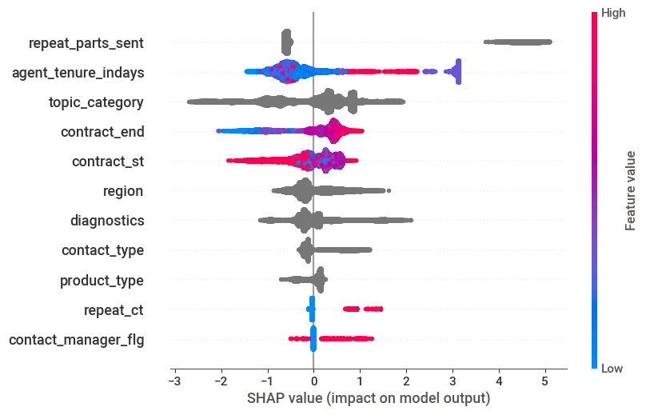

```python
shap.summary_plot(shap_values, X)
```

Local Interpretability

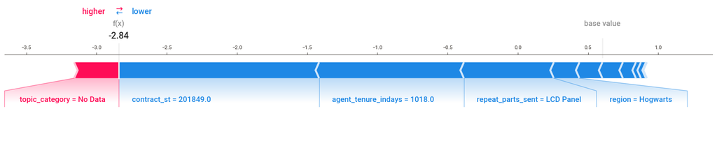

```python
shap.force_plot(explainer.expected_value, shap_values[0,:], X_train.iloc[0,:], matplotlib=True)
```

```python
X_train.iloc[0]
```

```
product_type             Laptops
contract_st               201849
contract_end              202139
contact_type               VOICE
topic_category           No Data
repeat_ct                      1
agent_tenure_indays         1018
contact_manager_flg            0
diagnostics             Not_USED
repeat_parts_sent      LCD Panel
region                  Hogwarts
Name: 58562, dtype: object
```

```python
y_train.iloc[0]
```

```
1
```

# Deployment Plan

As far as deploying above model the following steps would need to be taken:

- Modularize code (split into .py files in meaningful sections (Data Intake, Feature Engineering, Modeling))
- Persist model, features used and encoding details (.pkl, .xml, yaml files)
- Decide on delivery mechanism (email, dashboard, integration with client front-end, etc.)
- Establish frequency of predictions and storage
- Architect solution taking into account end user desires and available technology
- Design production pipeline for live data refresh
- Develop model monitoring framework
- Continuously iterate and improve solution leveraging user feedback

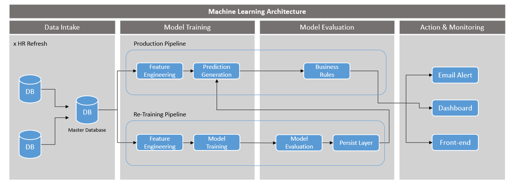

# Success Metrics

A very important aspect of every ML project is capturing it's impact.

In order to do so Sucess Metrics or KPI's must be defined.

Additionally a Pilot or test period must be agreed upon and implemented to ensure model usefulness before rolling out to entire client base.

In this project where we predict the case repair type (Hard/Soft) some metrics that could be calcuated are:

- Percent of True Positives or Cases that were predicted as Hardware repairs and where actually Hardware repairs (ensure that is above a number agreed with business)
- Percent of True Positives or Cases that were predicted as Software repairs and where actually Software repairs (ensure that is above a number agreed with business)
- Calculate difference in overall case completion time between cases that received alerts and those that didnt.

and here is a pilot plan that could be followed:

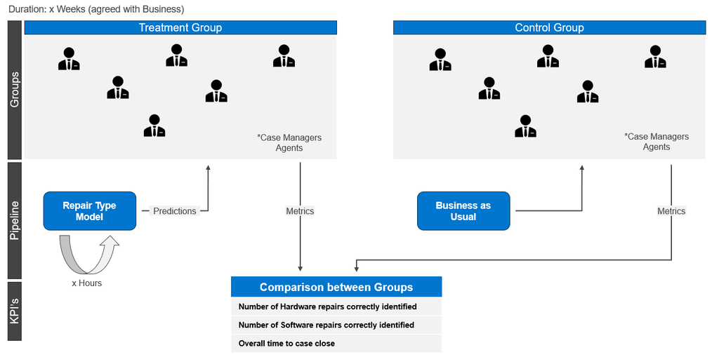